# Machine Learning Foundation

## Course 6, Part f: SARIMA and Prophet DEMO

## Learning Outcomes

You should walk away from this notebook with:

1. A practical understanding of Autoregressive Integrated Moving Average (ARIMA) models.
2. Insight into checking fit of model.
3. Learn to create forecasts with ARIMA models in Python.
4. A practical understanding of fbprophet
5. How to check fit of fbprophet model
6. Means of adjusting and improving fbprophet model parameters

# Overview: Time Series Modeling Approaches

In previous lessons, we explored Python implementations of fundamental time series concepts including stationarity, smoothing, trend, seasonality, and autocorrelation, and built two kinds of models:

- **MA models**: Specify that the current value of the series depends linearly on the series' mean and a set of prior (observed) white noise error terms.
- **AR models**: Specify that the current value of the series depends linearly on its own previous values and on a stochastic term (an imperfectly predictable term).

In the current lesson we will review these concepts as well as combine these two model types into three more complicated time series models: ARMA, ARIMA, and SARIMA. We will then explore a different type of Time Series modeling using **[Facebook Prophet](https://facebook.github.io/prophet/https://facebook.github.io/prophet/)**.

**Installation notes:**

[Prophet holiday issues](https://stackoverflow.com/questions/60145006/cannot-import-name-easter-from-holidays)

To install **[pdarima](https://pypi.org/project/pmdarima/)** on Anaconda, use:

[conda install -c saravji pdarima](https://anaconda.org/saravji/pmdarima)

```python
# Setup
from datetime import datetime
import matplotlib
import matplotlib.pyplot as plt
import numpy as np
import pandas as pd
import statsmodels.api as sm
import seaborn as sns
import sys, os
#os.chdir('data')
from colorsetup import colors, palette
sns.set_palette(palette)
import warnings
warnings.simplefilter(action='ignore')
import fbprophet
import pmdarima as pm
```

[output not shown]

```python
from statsmodels.tsa.statespace.sarimax import SARIMAX
```

# Section 1: Time Series Review

We've covered lots of material in the previous four lessons. Now is a good time to step back and rehash what we've covered. This will help to both solidify concepts and ensure you're ready to tackle ARMA, ARIMA, and SARIMA models.

### Section 1.1: Examples of time series data and modeling:

- Hedge fund prediction of stock and index movements
- Long and short-term weather forecasting
- Business budgeting and trend analysis
- Health vitals monitoring
- Traffic flows and logistic optimization modeling
- Can you think of others?

### Section 1.2: Decomposition

Time series data can often be decomposed into trend, seasonal, and random fluctuation components.

Decomposition

- Trends
  - Up
  - Down
  - Flat
  - Larger trends can be made up of smaller trends
  - There is no defined timeframe for what constitutes a trend as it depends on your goals
- Seasonal Effects
  - Weekend retail sales spikes
  - Holiday shopping
  - Energy requirement changes with annual weather patterns
  - Note: Twitter spikes when news happens are not seasonal because they aren't regular and predictable
- Random Fluctuations
  - The human element
  - Aggregations of small influencers
  - Observation errors
  - The smaller this is in relation to Trend and Seasonal, the better we can predict the future

### Section 1.3: Additive vs Multiplicative

Time series models fall into [two camps](http://www.abs.gov.au/websitedbs/D3310114.nsf/home/Time+Series+Analysis:+The+Basics#HOW%20DO%20I%20KNOW%20WHICH%20DECOMPOSITION):

- Additive
  - Data = Trend + Seasonal + Random
  - What we will be using for our modeling
- Multiplicative
  - Data = Trend x Seasonal x Random
  - As easy to fit as Additive if we take the log
    - log(Data) = log(Trend x Seasonal x Random)

We should use multiplicative models when the percentage change of our data is more important than the absolute value change (e.g. stocks, commodities); as the trend rises and our values grow, we see amplitude growth in seasonal and random fluctuations. If our seasonality and fluctuations are stable, we likely have an additive model.

### Section 1.4: Time Series Modeling Process

Time series model selection is driven by the Trend and Seasonal components of our raw data. The general approach for analysis looks like this:

1. Plot the data and determine Trends and Seasonality
   1. Difference or take the log of the data (multiple times if needed) to remove trends for [certain model applications](https://en.wikipedia.org/wiki/Stationary_process)
   2. Stationairity is needed for ARMA models
2. Determine if we have additive or multiplicative data patterns
3. Select the appropriate algorithm based on the chart below
4. Determine if model selection is correct with these tools
   - Ljung-Box Test
   - Residual Errors (Normal Distribution with zero mean and constant variance-homoskedastic, i.i.d)
   - Autocorrelation Function (ACF)
   - Partial Autocorrelation Function (PACF)

| Algorithm | Trend | Seasonal | Correlations |
| --- | --- | --- | --- |
| ARIMA | X | X | X |
| SMA Smoothing | X |  |  |
| Simple Exponential Smoothing | X |  |  |
| Seasonal Adjustment | X | X |  |
| Holt's Exponential Smoothing | X |  |  |
| Holt-Winters | X | X |  |

### Section 1.5: How to Achieve and Test for Stationarity

- The mean of the series is not a function of time.
- The variance of the series is not a function of time (homoscedasticity).
- The covariance at different lags is not a function of time.

[From A Complete Tutorial on Time Series Modeling in R](https://www.analyticsvidhya.com/blog/2015/12/complete-tutorial-time-series-modeling/)

- [Info on stationarity](http://www.investopedia.com/articles/trading/07/stationary.asp)
- Plotting Rolling Statistics
  - Plot the moving average/variance and see if it changes with time. This visual technique can be done on different windows, but isn't as rigorously defensible as the test below.
- Augmented Dickey-Fuller Test
  - Statistical tests for checking stationarity; the null hypothesis is that the TS is non-stationary. If our test statistic is below an `alpha` value, we *can* reject the null hypothesis and say that the series is stationary.

  $$ Y_t = \rho * Y_{t-1} + \epsilon_t $$

  $$ Y_t - Y_{t-1} = (\rho - 1) Y_{t - 1} + \epsilon_t $$

### Section 1.6: Differencing Example

This will give us a reminder to how differencing is used to get a stationary series which will be essential to the final piece of the ARIMA model

```python
# create a play dataframe from 1-10 (linear and squared) to test how differencing works
play = pd.DataFrame([[x for x in range(1,11)], [x**2 for x in range(1,11)]]).T
play.columns = ['original', 'squared']
play
```

|  | original | squared |
| --- | --- | --- |
| 0 | 1 | 1 |
| 1 | 2 | 4 |
| 2 | 3 | 9 |
| 3 | 4 | 16 |
| 4 | 5 | 25 |
| 5 | 6 | 36 |
| 6 | 7 | 49 |
| 7 | 8 | 64 |
| 8 | 9 | 81 |
| 9 | 10 | 100 |

```python
# stationarize linear series (mean and variance don't change for sub-windows)
play.original.diff()
```

```
0    NaN
1    1.0
2    1.0
3    1.0
4    1.0
5    1.0
6    1.0
7    1.0
8    1.0
9    1.0
Name: original, dtype: float64
```

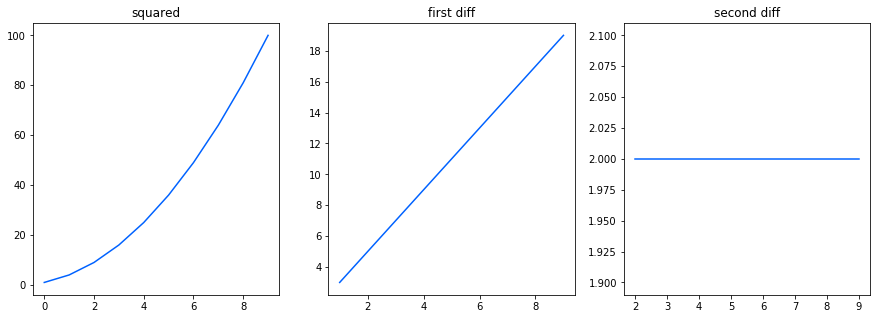

```python
fig,axes = plt.subplots(1,3,figsize = (15,5))
axes[0].plot(play.squared)
axes[0].set_title('squared')
axes[1].plot(play.squared.diff())
axes[1].set_title('first diff')
axes[2].plot(play.squared.diff().diff())
axes[2].set_title('second diff')
```

**NOTE:** This is similar to taking a first-order derivative.

```python
# stationarize squared series
play.squared.diff().diff()
```

```
0    NaN
1    NaN
2    2.0
3    2.0
4    2.0
5    2.0
6    2.0
7    2.0
8    2.0
9    2.0
Name: squared, dtype: float64
```

```python
# stationarize squared with log
np.log(play.squared)
```

```
0    0.000000
1    1.386294
2    2.197225
3    2.772589
4    3.218876
5    3.583519
6    3.891820
7    4.158883
8    4.394449
9    4.605170
Name: squared, dtype: float64
```

**NOTE:** Works somewhat but certainly not as well.

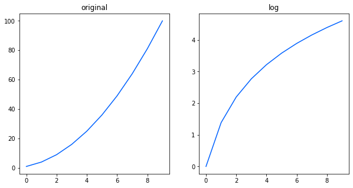

```python
fig,axes = plt.subplots(1,2,figsize = (10,5))
axes[0].plot(play.squared)
axes[0].set_title('original')
axes[1].plot(np.log(play.squared))
axes[1].set_title('log')
```

## Data Prep and EDA

We'll be looking at [monthly average temperatures between 1907-1972](https://datamarket.com/data/set/22o4/mean-monthly-temperature-1907-1972#!ds=22o4&display=line)

```python
# load data and convert to datetime
monthly_temp = pd.read_csv('./mean-monthly-temperature-1907-19.csv',
                           skipfooter=2,
                           infer_datetime_format=True,
                           header=0,
                           index_col=0, engine='python',
                           names=['month', 'temp'])

monthly_temp.index = pd.to_datetime(monthly_temp.index)
```

```python
monthly_temp.head()
```

| month | temp |
| --- | --- |
| 1907-01-01 | 33.3 |
| 1907-02-01 | 46.0 |
| 1907-03-01 | 43.0 |
| 1907-04-01 | 55.0 |
| 1907-05-01 | 51.8 |

```python
# describe
monthly_temp.describe()
```

|  | temp |
| --- | --- |
| count | 792.000000 |
| mean | 53.553662 |
| std | 15.815452 |
| min | 11.200000 |
| 25% | 39.675000 |
| 50% | 52.150000 |
| 75% | 67.200000 |
| max | 82.400000 |

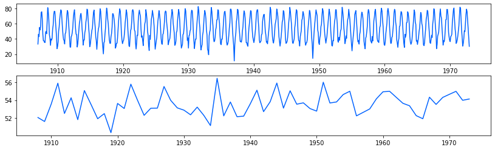

```python
# resample to annual and plot each
plt.rcParams['figure.figsize'] = [14, 4]
annual_temp = monthly_temp.resample('A').mean()
fig, axes = plt.subplots(2,1)
axes[0].plot(monthly_temp)
axes[1].plot(annual_temp)
```

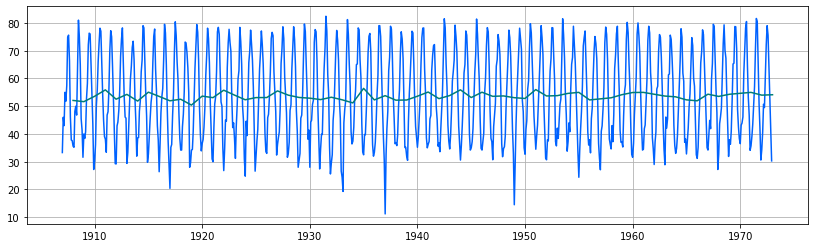

```python
# plot both on same figure
plt.plot(monthly_temp)
plt.plot(annual_temp)
plt.grid(b=True);
```

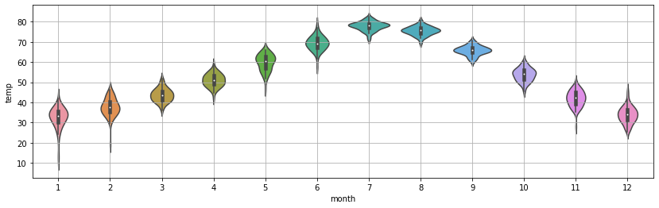

```python
# violinplot of months to determine variance and range
sns.violinplot(x=monthly_temp.index.month, y=monthly_temp.temp)
plt.grid(b=True);
```

```python
# split data into 10 chunks
chunks = np.split(monthly_temp.temp, indices_or_sections=12)
```

```python
mean_vals = np.mean(chunks,axis=1)
var_vals = np.var(chunks,axis=1)
vals = {'mean_vals': mean_vals , 'var_vals': var_vals}
mean_var = pd.DataFrame(vals)
mean_var
```

|  | mean_vals | var_vals |
| --- | --- | --- |
| 0 | 52.674242 | 225.907973 |
| 1 | 53.654545 | 246.031570 |
| 2 | 52.837879 | 247.400838 |
| 3 | 54.078788 | 250.787429 |
| 4 | 52.439394 | 277.865721 |
| 5 | 53.457576 | 283.619412 |
| 6 | 53.718182 | 224.882397 |
| 7 | 54.422727 | 265.442059 |
| 8 | 53.457576 | 238.561230 |
| 9 | 54.425758 | 257.425852 |
| 10 | 52.613636 | 219.026026 |
| 11 | 54.863636 | 253.827466 |

```python
# define Dickey-Fuller Test (DFT) function
# Null is that unit root is present, rejection means likely stationary
import statsmodels.tsa.stattools as ts
def dftest(timeseries):
    dftest = ts.adfuller(timeseries,)
    dfoutput = pd.Series(dftest[0:4],
                         index=['Test Statistic','p-value','Lags Used','Observations Used'])
    for key,value in dftest[4].items():
        dfoutput['Critical Value (%s)'%key] = value
    print(dfoutput)
    #Determing rolling statistics
    rolmean = timeseries.rolling(window=12).mean()
    rolstd = timeseries.rolling(window=12).std()

    #Plot rolling statistics:
    orig = plt.plot(timeseries, color='blue',label='Original')
    mean = plt.plot(rolmean, color='red', label='Rolling Mean')
    std = plt.plot(rolstd, color='black', label = 'Rolling Std')
    plt.legend(loc='best')
    plt.title('Rolling Mean and Standard Deviation')
    plt.grid()
    plt.show(block=False)
```

```
Test Statistic         -6.481466e+00
p-value                 1.291867e-08
Lags Used               2.100000e+01
Observations Used       7.700000e+02
Critical Value (1%)    -3.438871e+00
Critical Value (5%)    -2.865301e+00
Critical Value (10%)   -2.568773e+00
dtype: float64
```

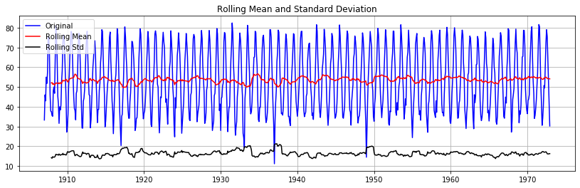

```python
# run DFT on monthly
dftest(monthly_temp.temp)
# p-value allows us to reject a unit root: data is stationary
```

```
Test Statistic         -7.878242e+00
p-value                 4.779473e-12
Lags Used               0.000000e+00
Observations Used       6.500000e+01
Critical Value (1%)    -3.535217e+00
Critical Value (5%)    -2.907154e+00
Critical Value (10%)   -2.591103e+00
dtype: float64
```

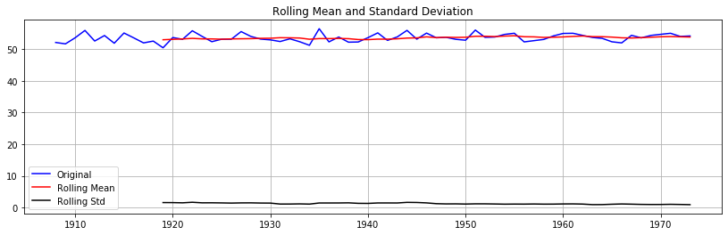

```python
# run DFT on annual
dftest(annual_temp.temp)
```

The p-value allows us to *reject* a unit root (i.e. the data is stationary).

```
Test Statistic          -0.449458
p-value                  0.901508
Lags Used               10.000000
Observations Used       55.000000
Critical Value (1%)     -3.555273
Critical Value (5%)     -2.915731
Critical Value (10%)    -2.595670
dtype: float64
```

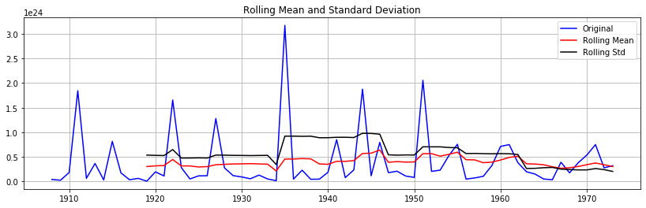

```python
# here's an example of non-stationary with DFT results
dftest(np.exp(annual_temp.temp))
```

```
INFO:numexpr.utils:NumExpr defaulting to 8 threads.
```

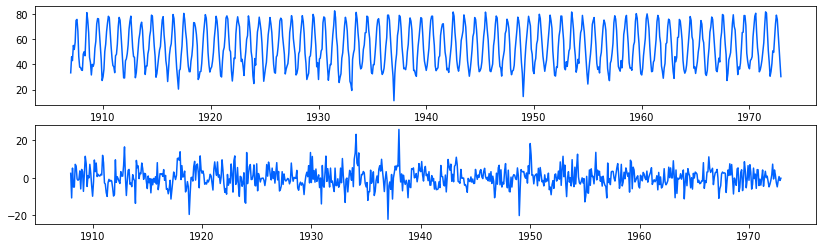

```python
# Important to note that values have strong seasonality and adf test as well as rolling mean may not capture this.
# That is why it is always important to pay attention to run sequence plot
monthly_temp['lag_12'] = monthly_temp.shift(12)
monthly_temp['seasonal_diff'] = monthly_temp.temp - monthly_temp['lag_12']

fig,axes = plt.subplots(2,1)
axes[0].plot(monthly_temp.temp,label ='original')
axes[1].plot(monthly_temp.seasonal_diff,label = 'seasonal diff')
```

## Section 2: SARIMA with Statsmodels

We went through getting stationary data and differencing as that is the last piece of the puzzle that we are missing for understanding ARIMA models. The I stands for "Integrated" which just refers to the amount of differcing done on the data.

When we are determining our ARIMA model we will come across the following standard inputs:

- order(p,d,q):
  - p is number of AR terms
  - d is number of times that we would difference our data
  - q is number of MA terms

When we work with SARIMA models 'S' refers to 'seasonal' and we have the additional standard inputs:

- seasonal order(p,d,q):
  - p is number of AR terms in regards to seasonal lag
  - d is number of times that we would difference our seasonal lag (as seen above)
  - q is number of MA terms in regards to seasonal lag
  - s is number of periods in a season

Reminder of some good resources:

- [ARIMA in R](https://www.otexts.org/fpp/8/5)
- [Duke ARIMA Guide](https://people.duke.edu/~rnau/411arim2.htm)
- [Great explanation on MA in practice](http://stats.stackexchange.com/questions/164824/moving-average-ma-process-numerical-intuition)

Some rules to highlight from the Duke ARIMA Guide:

1. If the series has positive autocorrelations out to a high number of lags, then it probably needs a higher order of differencing
2. If the lag-1 autocorrelation is zero or negative, or the autocorrelations are all small and patternless, then the series does not need a higher order of differencing. If the lag-1 autocorrelation is -0.5 or more negative, the series may be overdifferenced. BEWARE OF OVERDIFFERENCING!!
3. A model with no orders of differencing assumes that the original series is stationary (mean-reverting). A model with one order of differencing assumes that the original series has a constant average trend (e.g. a random walk or SES-type model, with or without growth). A model with two orders of total differencing assumes that the original series has a time-varying trend (e.g. a random trend or LES-type model)

### Create Helper Functions

```python
# define helper plot function for visualization
def plots(data, lags=None):
    layout = (1, 3)
    raw  = plt.subplot2grid(layout, (0, 0))
    acf  = plt.subplot2grid(layout, (0, 1))
    pacf = plt.subplot2grid(layout, (0, 2))

    raw.plot(data)
    sm.tsa.graphics.plot_acf(data, lags=lags, ax=acf, zero=False)
    sm.tsa.graphics.plot_pacf(data, lags=lags, ax=pacf, zero = False)
    sns.despine()
    plt.tight_layout()
```

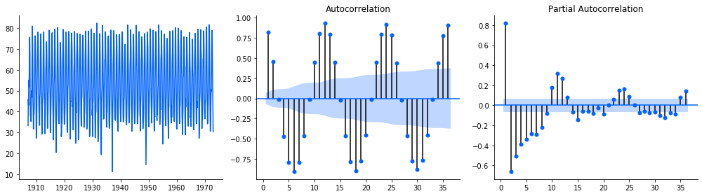

```python
# helper plot for monthly temps
plots(monthly_temp.temp, lags=36);
# open Duke guide for visual
# we note a 12-period cycle (yearly) with suspension bridge design, so must use SARIMA
```

### [Box-Jenkins Method](https://en.wikipedia.org/wiki/Box%E2%80%93Jenkins_method)

| ACF Shape | Indicated Model |
| --- | --- |
| Exponential, decaying to zero | Autoregressive model. Use the partial autocorrelation plot to identify the order of the autoregressive model. |
| Alternating positive and negative, decaying to zero | Autoregressive model. Use the partial autocorrelation plot to help identify the order. |
| One or more spikes, rest are essentially zero | Moving average model, order identified by where plot becomes zero. |
| Decay, starting after a few lags | Mixed autoregressive and moving average (ARMA) model. |
| All zero or close to zero | Data are essentially random. |
| High values at fixed intervals | Include seasonal autoregressive term. |
| No decay to zero | Series is not stationary. |

```python
# we might need to install dev version for statespace functionality
#!pip install git+https://github.com/statsmodels/statsmodels.git

# fit SARIMA monthly based on helper plots
sar = sm.tsa.statespace.SARIMAX(monthly_temp.temp,
                                order=(1,0,0),
                                seasonal_order=(0,1,1,12),
                                trend='c').fit()
sar.summary()
```

SARIMAX Results

| Dep. Variable: | temp | No. Observations: | 792 |
| --- | --- | --- | --- |
| Model: | SARIMAX(1, 0, 0)x(0, 1, [1], 12) | Log Likelihood | -2128.873 |
| Date: | Tue, 16 Jun 2020 | AIC | 4265.746 |
| Time: | 11:28:04 | BIC | 4284.383 |
| Sample: | 01-01-1907 | HQIC | 4272.914 |
|  | - 12-01-1972 |  |  |
| Covariance Type: | opg |  |  |

|  | coef | std err | z | P>\|z\| | [0.025 | 0.975] |
| --- | --- | --- | --- | --- | --- | --- |
| intercept | 0.0127 | 0.007 | 1.697 | 0.090 | -0.002 | 0.027 |
| ar.L1 | 0.1791 | 0.035 | 5.105 | 0.000 | 0.110 | 0.248 |
| ma.S.L12 | -0.9996 | 1.368 | -0.731 | 0.465 | -3.681 | 1.681 |
| sigma2 | 12.8928 | 17.515 | 0.736 | 0.462 | -21.437 | 47.222 |

| Ljung-Box (Q): | 27.91 | Jarque-Bera (JB): | 252.77 |
| --- | --- | --- | --- |
| Prob(Q): | 0.93 | Prob(JB): | 0.00 |
| Heteroskedasticity (H): | 0.71 | Skew: | -0.56 |
| Prob(H) (two-sided): | 0.01 | Kurtosis: | 5.55 |

Warnings:  
[1] Covariance matrix calculated using the outer product of gradients (complex-step).

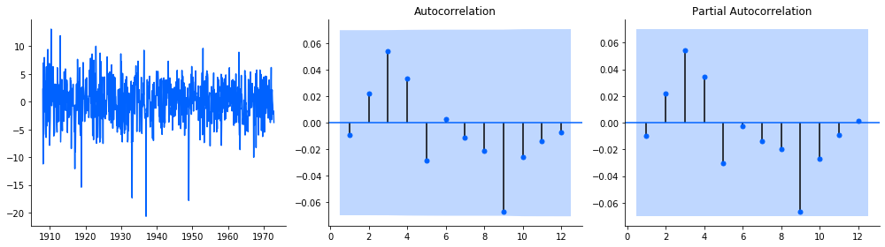

```python
# plot resids
plots(sar.resid[sar.loglikelihood_burn:], lags=12);
```

**Thought process:**

010010 is probably overdifferenced as we can see by negative ACF at lag 1

000010 is a big underdiff at seasonal lag, but with better AIC

Looks like 000010,12 and Trend='c' per rule

Looking back at seasonal we notice negative ACR spike at 12: we will thus add a SMA term and we see a big drop in AIC to 4289

looks like ACF looks good at seasonal lags, so we move back to ARIMA portion.

ACF shows we can use AR terms. AR=1,2 or 3 have similar AIC

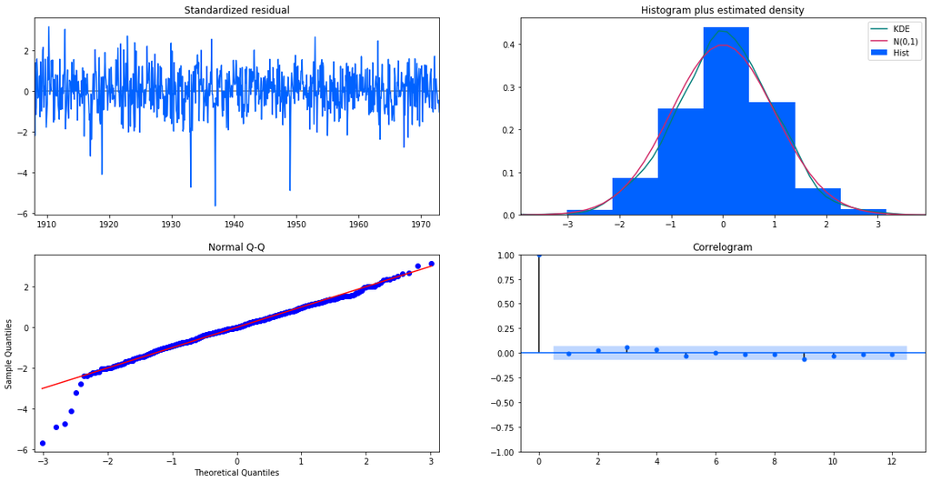

```python
# plot residual diagnostics
sar.plot_diagnostics(lags=12,figsize = (20,10),);
```

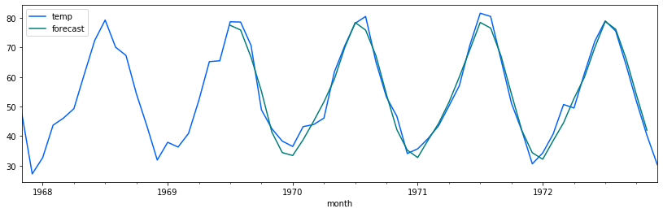

```python
# plot predictions
pd.plotting.register_matplotlib_converters()
#use model.predict() start and end in relation to series
monthly_temp['forecast'] = sar.predict(start = 750, end= 790)
monthly_temp[730:][['temp', 'forecast']].plot();
```

```python
#Introducing another model
sar2 = sm.tsa.statespace.SARIMAX(monthly_temp.temp,
                                order=(3,0,0),
                                seasonal_order=(0,1,1,12),
                                trend='c').fit()
```

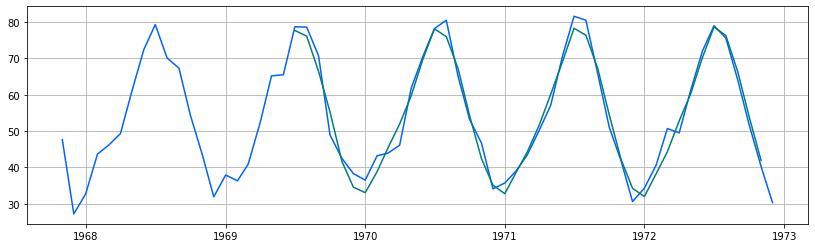

```python
# plot predictions
monthly_temp['forecast'] = sar2.predict(start = 750, end= 790, dynamic=False)
plt.plot(monthly_temp[730:][['temp', 'forecast']])
plt.grid();
```

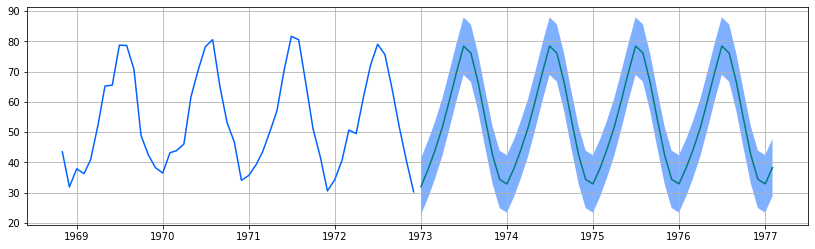

```python
# can use get forecast to create a forecast object
future_fcst = sar2.get_forecast(50)
# That will have a method to pull in confidence interval
confidence_int = future_fcst.conf_int(alpha = 0.01)
# Has an attribute to pull in predicted mean
fcst = future_fcst.predicted_mean
# Plot predictions and confidence intervals
plt.plot(monthly_temp.temp[-50:])
plt.plot(fcst)
plt.fill_between(confidence_int.index,confidence_int['lower temp'],confidence_int['upper temp'],alpha = 0.5)
plt.grid()
```

## Section 3: Statistical Tests

- [Normality (Jarque-Bera)](http://www.statsmodels.org/dev/generated/statsmodels.tsa.statespace.sarimax.SARIMAXResults.test_normality.html#statsmodels.tsa.statespace.sarimax.SARIMAXResults.test_normality)
  - Null hypothesis is normally distributed residuals (good, plays well with RMSE and similar error metrics)
- [Serial correlation (Ljung-Box)](http://www.statsmodels.org/dev/generated/statsmodels.tsa.statespace.sarimax.SARIMAXResults.test_serial_correlation.html#statsmodels.tsa.statespace.sarimax.SARIMAXResults.test_serial_correlation)
  - Null hypothesis is no serial correlation in residuals (independent of each other)
- [Heteroskedasticity](http://www.statsmodels.org/dev/generated/statsmodels.tsa.statespace.sarimax.SARIMAXResults.test_heteroskedasticity.html#statsmodels.tsa.statespace.sarimax.SARIMAXResults.test_heteroskedasticity)
  - Tests for change in variance between residuals.
  - The null hypothesis is no heteroskedasticity. That means different things depending on which alternative is selected:
    - Increasing: Null hypothesis is that the variance is not increasing throughout the sample; that the sum-of-squares in the later subsample is not greater than the sum-of-squares in the earlier subsample.
    - Decreasing: Null hypothesis is that the variance is not decreasing throughout the sample; that the sum-of-squares in the earlier subsample is not greater than the sum-of-squares in the later subsample.
    - Two-sided (default): Null hypothesis is that the variance is not changing throughout the sample. Both that the sum-of-squares in the earlier subsample is not greater than the sum-of-squares in the later subsample and that the sum-of-squares in the later subsample is not greater than the sum-of-squares in the earlier subsample.
- [Durbin Watson](https://en.wikipedia.org/wiki/Durbin%E2%80%93Watson_statistic)
  - Tests autocorrelation of residuals: we want between 1-3, 2 is ideal (no serial correlation)

```python
sar.test_normality?
```

```
Signature: sar.test_normality(method)
Docstring:
Test for normality of standardized residuals.

Null hypothesis is normality.

Parameters
----------
method : {'jarquebera', None}
    The statistical test for normality. Must be 'jarquebera' for
    Jarque-Bera normality test. If None, an attempt is made to select
    an appropriate test.

Notes
-----
Let `d` = max(loglikelihood_burn, nobs_diffuse); this test is
calculated ignoring the first `d` residuals.

In the case of missing data, the maintained hypothesis is that the
data are missing completely at random. This test is then run on the
standardized residuals excluding those corresponding to missing
observations.

See Also
--------
statsmodels.stats.stattools.jarque_bera
    The Jarque-Bera test of normality.
File:      /Applications/anaconda3/lib/python3.7/site-packages/statsmodels/tsa/statespace/mlemodel.py
Type:      method
```

```python
# create and run statistical tests on model
norm_val, norm_p, skew, kurtosis = sar.test_normality('jarquebera')[0]
lb_val, lb_p = sar.test_serial_correlation(method='ljungbox',)[0]
het_val, het_p = sar.test_heteroskedasticity('breakvar')[0]


# we want to look at largest lag for Ljung-Box, so take largest number in series
# there's intelligence in the method to determine how many lags back to calculate this stat
lb_val = lb_val[-1]
lb_p = lb_p[-1]
durbin_watson = sm.stats.stattools.durbin_watson(
    sar.filter_results.standardized_forecasts_error[0, sar.loglikelihood_burn:])

print('Normality: val={:.3f}, p={:.3f}'.format(norm_val, norm_p));
print('Ljung-Box: val={:.3f}, p={:.3f}'.format(lb_val, lb_p));
print('Heteroskedasticity: val={:.3f}, p={:.3f}'.format(het_val, het_p));
print('Durbin-Watson: d={:.2f}'.format(durbin_watson))
```

```
Normality: val=252.770, p=0.000
Ljung-Box: val=27.915, p=0.925
Heteroskedasticity: val=0.708, p=0.006
Durbin-Watson: d=2.01
```

### Note on autofit methods

R has an autoARIMA function (and other automagic methods) that gridsearches/optimizes our model hyperparameters for us. Over time, more of these goodies are porting to Python (e.g. pmdarima). While there's nothing wrong with utilizing these resources, the *human makes the final determination!* Don't become over-reliant on these methods, especially early on when you are grasping the underlying mechanics and theory!

```python
#from pyramid.arima import auto_arima
stepwise_model = pm.auto_arima(monthly_temp.temp, start_p=1, start_q=1,
                           max_p=3, max_q=3, m=12,
                           start_P=0, seasonal=True,
                           d=0, D=1, trace=True,
                           error_action='ignore',
                           suppress_warnings=True,
                           stepwise=True)
print(stepwise_model.aic())
```

```
Fit ARIMA: order=(1, 0, 1) seasonal_order=(0, 1, 1, 12); AIC=4265.781, BIC=4289.077, Fit time=2.590 seconds
Fit ARIMA: order=(0, 0, 0) seasonal_order=(0, 1, 0, 12); AIC=4796.839, BIC=4806.158, Fit time=0.040 seconds
Fit ARIMA: order=(1, 0, 0) seasonal_order=(1, 1, 0, 12); AIC=4546.179, BIC=4564.816, Fit time=0.664 seconds
Fit ARIMA: order=(0, 0, 1) seasonal_order=(0, 1, 1, 12); AIC=4267.567, BIC=4286.204, Fit time=1.673 seconds
Fit ARIMA: order=(1, 0, 1) seasonal_order=(1, 1, 1, 12); AIC=4267.267, BIC=4295.223, Fit time=3.281 seconds
Fit ARIMA: order=(1, 0, 1) seasonal_order=(0, 1, 0, 12); AIC=4767.543, BIC=4786.180, Fit time=0.271 seconds
Fit ARIMA: order=(1, 0, 1) seasonal_order=(0, 1, 2, 12); AIC=4267.235, BIC=4295.190, Fit time=8.678 seconds
Fit ARIMA: order=(1, 0, 1) seasonal_order=(1, 1, 2, 12); AIC=4269.045, BIC=4301.660, Fit time=7.571 seconds
Fit ARIMA: order=(2, 0, 1) seasonal_order=(0, 1, 1, 12); AIC=4267.467, BIC=4295.423, Fit time=1.955 seconds
Fit ARIMA: order=(1, 0, 0) seasonal_order=(0, 1, 1, 12); AIC=4265.746, BIC=4284.383, Fit time=1.690 seconds
Fit ARIMA: order=(1, 0, 0) seasonal_order=(1, 1, 1, 12); AIC=4267.159, BIC=4290.455, Fit time=1.953 seconds
Fit ARIMA: order=(1, 0, 0) seasonal_order=(0, 1, 0, 12); AIC=4769.737, BIC=4783.715, Fit time=0.112 seconds
Fit ARIMA: order=(1, 0, 0) seasonal_order=(0, 1, 2, 12); AIC=4267.125, BIC=4290.422, Fit time=5.787 seconds
Fit ARIMA: order=(1, 0, 0) seasonal_order=(1, 1, 2, 12); AIC=4269.204, BIC=4297.160, Fit time=5.260 seconds
Fit ARIMA: order=(0, 0, 0) seasonal_order=(0, 1, 1, 12); AIC=4289.161, BIC=4303.139, Fit time=1.121 seconds
Fit ARIMA: order=(2, 0, 0) seasonal_order=(0, 1, 1, 12); AIC=4266.874, BIC=4290.170, Fit time=2.168 seconds
Total fit time: 44.818 seconds
4265.745875119801
```

```python
from dateutil.relativedelta import relativedelta
def future_preds_df(model,series,num_months):
    pred_first = series.index.max()+relativedelta(months=1)
    pred_last = series.index.max()+relativedelta(months=num_months)
    date_range_index = pd.date_range(pred_first,pred_last,freq = 'MS')
    vals = model.predict(n_periods = num_months)
    return pd.DataFrame(vals,index = date_range_index)
```

```python
preds = future_preds_df(stepwise_model,monthly_temp.temp,100)
```

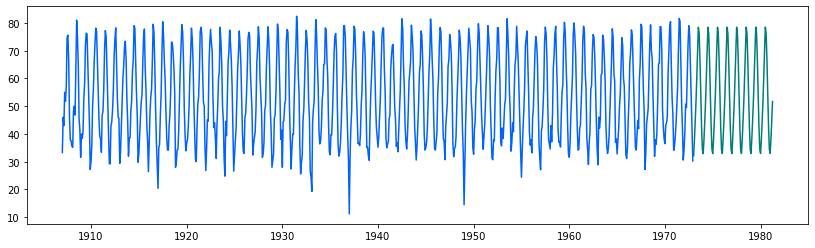

```python
plt.plot(monthly_temp.temp)
plt.plot(preds)
```

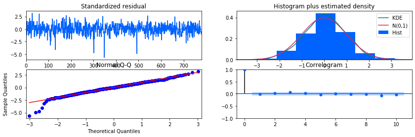

```python
stepwise_model.plot_diagnostics();
```

```python
print('auto-fit order: :', stepwise_model.order)
print('auto-fit seasonal_order: :', stepwise_model.seasonal_order)
```

```
auto-fit order: : (1, 0, 0)
auto-fit seasonal_order: : (0, 1, 1, 12)
```

When deciding on a model, often what truly matters is how well we would be able to produce out of sample predictions. Here we create a function that looks at multiple out of sample predictions to see which model had lowest out of sample error

```python
def cross_validate(series,horizon,start,step_size,order = (1,0,0),seasonal_order = (0,0,0,0),trend=None):
    '''
    Function to determine in and out of sample testing of arima model

    arguments
    ---------
    series (seris): time series input
    horizon (int): how far in advance forecast is needed
    start (int): starting location in series
    step_size (int): how often to recalculate forecast
    order (tuple): (p,d,q) order of the model
    seasonal_order (tuple): (P,D,Q,s) seasonal order of model

    Returns
    -------
    DataFrame: gives fcst and actuals with date of prediction
    '''
    fcst = []
    actual = []
    date = []
    for i in range(start,len(series)-horizon,step_size):
        model = sm.tsa.statespace.SARIMAX(series[:i+1], #only using data through to and including start
                                order=order,
                                seasonal_order=seasonal_order,
                                trend=trend).fit()
        fcst.append(model.forecast(steps = horizon)[-1]) #forecasting horizon steps into the future
        actual.append(series[i+horizon]) # comparing that to actual value at that point
        date.append(series.index[i+horizon]) # saving date of that value
    return pd.DataFrame({'fcst':fcst,'actual':actual},index=date)
```

```python
warnings.filterwarnings("ignore")
series = monthly_temp.temp
horizon = 12
start = 700
step_size = 3
order = (1,0,0)
seasonal_order = (0,1,1,12)

cv1 = cross_validate(monthly_temp.temp,12,700,3,
                    order = order,
                    seasonal_order = seasonal_order)
```

```python
#example to see underpinning of cv


model = sm.tsa.statespace.SARIMAX(series[:701], #only using data through start of 700
                                order=order,
                                seasonal_order=seasonal_order,
                                trend=None).fit()
```

```python
#end of input
series[:701].tail()
```

```
month
1965-01-01    32.8
1965-02-01    37.8
1965-03-01    42.0
1965-04-01    49.8
1965-05-01    54.5
Name: temp, dtype: float64
```

```python
#value to predict horizon steps into the future
series[712:713]
```

```
month
1966-05-01    65.6
Name: temp, dtype: float64
```

```python
# what model predicted for that date
model.forecast(12)[-1:]
```

```
1966-05-01    59.580988
Freq: MS, dtype: float64
```

```python
cv1.head()
```

|  | fcst | actual |
| --- | --- | --- |
| 1966-05-01 | 59.580988 | 65.6 |
| 1966-08-01 | 75.351411 | 75.8 |
| 1966-11-01 | 41.607102 | 45.3 |
| 1967-02-01 | 37.584439 | 39.6 |
| 1967-05-01 | 59.753915 | 59.6 |

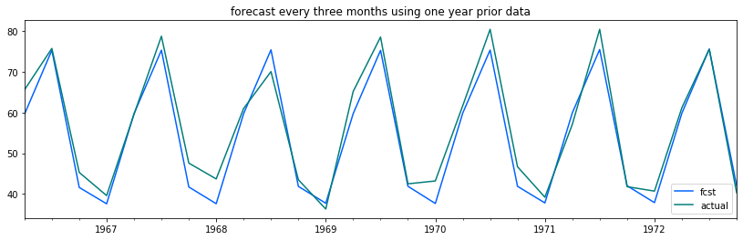

```python
cv1.plot(title = 'forecast every three months using one year prior data')
```

```python
#Defining an error metric to see out of sample accuracy
def mape(df_cv):
    return abs(df_cv.actual - df_cv.fcst).sum() / df_cv.actual.sum()
```

```python
mape(cv1)
```

```
0.05214814790939277
```

```python
warnings.filterwarnings("ignore")
series = monthly_temp.temp
horizon = 12
start = 700
step_size = 3
order = (1,1,0)
seasonal_order = (0,1,1,12)

cv2 = cross_validate(monthly_temp.temp,12,700,3,
                    order = order,
                    seasonal_order = seasonal_order)
```

```python
mape(cv2)
```

```
0.06835834478161248
```

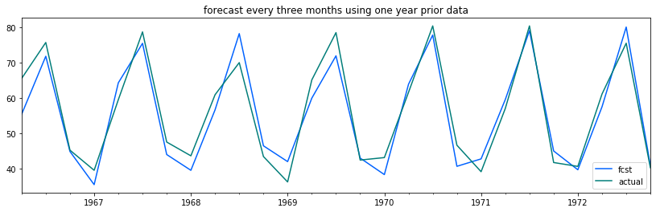

```python
cv2.plot(title = 'forecast every three months using one year prior data')
```

```python
mape(cv2)
```

```
0.06835834478161248
```

```python
len(monthly_temp.temp)
```

```
792
```

```python
def grid_search_ARIMA(series,horizon,start,step_size,orders = [(1,0,0)],seasonal_orders = [(0,0,0,0)],trends=[None]):
    best_mape = np.inf
    best_order = None
    best_seasonal_order = None
    best_trend = None
    for order_ in orders:
        for seasonal_order_ in seasonal_orders:
            for trend_ in trends:

                cv = cross_validate(series,
                                    horizon,
                                    start,
                                    step_size,
                                    order = order_,
                                    seasonal_order = seasonal_order_,
                                    trend=trend_)
                if mape(cv)<best_mape:
                    best_mape = mape(cv)
                    best_order = order_
                    best_seasonal_order = seasonal_order_
                    best_trend = trend_
    return (best_order,best_seasonal_order, best_trend, best_mape)
```

```python
series = monthly_temp.temp
horizon = 12
start = 760
step_size = 3
orders = [(1,1,0),(1,0,0)]
seasonal_orders = [(0,1,1,12)]
trends = [None,'c']

grid_search_ARIMA(series = series,
                  horizon = horizon,
                  start = start,
                  step_size = step_size,
                  orders = orders,
                  seasonal_orders = seasonal_orders,
                  trends=trends)
```

```
((1, 0, 0), (0, 1, 1, 12), None, 0.03513163490408245)
```